# Stacked Model (GFI)

Hip Hip Array

12/03/2021

# 1 Install packages and Load Data

```r
library(nflfastR)

future::plan("multisession")
pbp <- load_pbp(2010:2020, file_type = "qs")
str(pbp)
```

```
## tibble [531,515 × 372] (S3: tbl_df/tbl/data.table/data.frame)
##  $ play_id                             : num [1:531515] 1 36 58 82 103 132 156 177 201 222 ...
##  $ game_id                             : chr [1:531515] "2010_01_ARI_STL" "2010_01_ARI_STL" "2010_01_ARI_STL" "2010_01_ARI_STL" ...
##  $ old_game_id                         : chr [1:531515] "2010091208" "2010091208" "2010091208" "2010091208" ...
##  $ home_team                           : chr [1:531515] "LA" "LA" "LA" "LA" ...
##  $ away_team                           : chr [1:531515] "ARI" "ARI" "ARI" "ARI" ...
##  $ season_type                         : chr [1:531515] "REG" "REG" "REG" "REG" ...
##  $ week                                : int [1:531515] 1 1 1 1 1 1 1 1 1 1 ...
##  $ posteam                             : chr [1:531515] NA "ARI" "ARI" "ARI" ...
##  $ posteam_type                        : chr [1:531515] NA "away" "away" "away" ...
##  $ defteam                             : chr [1:531515] NA "LA" "LA" "LA" ...
##  $ side_of_field                       : chr [1:531515] NA "LA" "ARI" "ARI" ...
##  $ yardline_100                        : num [1:531515] NA 30 78 78 73 55 38 36 24 22 ...
##  $ game_date                           : chr [1:531515] "2010-09-12" "2010-09-12" "2010-09-12" "2010-09-12" ...
##  $ quarter_seconds_remaining           : num [1:531515] 900 900 895 864 823 797 772 727 701 663 ...
```

[output cut: 86 more lines]

```r
# library(gdata)
# pbp$year <- left(pbp$game_date, n=4)
```

## 1.1 Set up “Going For It” (GFI) Data

```r
# Only pull plays that are a fourth down attempt
GFI <- pbp[!is.na(pbp$play_type), ]
GFI <- GFI[!is.na(GFI$play_id) & GFI$down == 4 & GFI$punt_attempt == 0 & GFI$field_goal_attempt == 0 & GFI$play_type != "no_play" & GFI$play_type != "qb_kneel", ]
```

## 1.2 Set up GFI data for all models

```r
# Using model.matrix to convert all the factors to dummy variables
# We are converting all of the factors into dummy variables as the input into knn has to be numeric
library(dplyr)

# Include all variables for step function, exclude NA rows
GFI_ALL <- GFI[!is.na(GFI$fourth_down_converted), ]

## Randomize the rows in the data (shuffling the rows)
set.seed(123)
GFI_ALL <- slice(GFI_ALL, sample(1:n()))
```

## 1.3 Variable Selection with GLM

### 1.3.1 Training

```r
GFI_GLM_ALL <- select(
  GFI_ALL,
  fourth_down_converted,
  season_type,
  week,
  posteam_type,
  yardline_100,
  quarter_seconds_remaining,
  half_seconds_remaining,
  game_seconds_remaining,
  game_half,
  qtr,
  goal_to_go,
  ydstogo,
  play_type,
  shotgun,
  no_huddle,
  home_timeouts_remaining,
  away_timeouts_remaining,
  timeout,
  posteam_timeouts_remaining,
  defteam_timeouts_remaining,
  posteam_score,
  defteam_score,
  score_differential,
  special_teams_play,
  fixed_drive,
  away_score,
  home_score,
  location,
  div_game,
  roof,
  surface,
  home_opening_kickoff
)
GFI_GLM_ALL <- GFI_GLM_ALL %>% mutate_if(is.character, as.factor)

GFI_GLM_ALL <- GFI_GLM_ALL %>% select(where(~ n_distinct(.) > 1))

train_set <- sample(1:nrow(GFI_GLM_ALL), 0.7 * nrow(GFI_GLM_ALL))

# Training set
gfi_glm_train <- GFI_GLM_ALL[train_set, ]
gfi_glm_validation <- GFI_GLM_ALL[-train_set, ]

library(stats)
model_glm <- glm(fourth_down_converted ~ ., data = gfi_glm_train, family = "binomial", control = list(maxit = 100))
model_glm <- step(model_glm, direction = "backward")
```

```
## Start:  AIC=5071.38
## fourth_down_converted ~ season_type + week + posteam_type + yardline_100 +
##     quarter_seconds_remaining + half_seconds_remaining + game_seconds_remaining +
##     game_half + qtr + goal_to_go + ydstogo + play_type + shotgun +
##     no_huddle + home_timeouts_remaining + away_timeouts_remaining +
##     timeout + posteam_timeouts_remaining + defteam_timeouts_remaining +
##     posteam_score + defteam_score + score_differential + special_teams_play +
##     fixed_drive + away_score + home_score + location + div_game +
##     roof + surface + home_opening_kickoff
##
##
## Step:  AIC=5071.38
## fourth_down_converted ~ season_type + week + posteam_type + yardline_100 +
##     quarter_seconds_remaining + half_seconds_remaining + game_seconds_remaining +
##     game_half + qtr + goal_to_go + ydstogo + play_type + shotgun +
##     no_huddle + home_timeouts_remaining + away_timeouts_remaining +
##     timeout + posteam_timeouts_remaining + defteam_timeouts_remaining +
##     posteam_score + defteam_score + special_teams_play + fixed_drive +
##     away_score + home_score + location + div_game + roof + surface +
##     home_opening_kickoff
##
##
## Step:  AIC=5071.38
## fourth_down_converted ~ season_type + week + posteam_type + yardline_100 +
##     quarter_seconds_remaining + half_seconds_remaining + game_seconds_remaining +
##     game_half + qtr + goal_to_go + ydstogo + play_type + shotgun +
##     no_huddle + home_timeouts_remaining + away_timeouts_remaining +
##     timeout + posteam_timeouts_remaining + posteam_score + defteam_score +
##     special_teams_play + fixed_drive + away_score + home_score +
##     location + div_game + roof + surface + home_opening_kickoff
##
##
## Step:  AIC=5071.38
## fourth_down_converted ~ season_type + week + posteam_type + yardline_100 +
##     quarter_seconds_remaining + half_seconds_remaining + game_seconds_remaining +
##     game_half + goal_to_go + ydstogo + play_type + shotgun +
##     no_huddle + home_timeouts_remaining + away_timeouts_remaining +
##     timeout + posteam_timeouts_remaining + posteam_score + defteam_score +
##     special_teams_play + fixed_drive + away_score + home_score +
##     location + div_game + roof + surface + home_opening_kickoff
```

[output cut: 442 more lines]

```
##                          Df Deviance    AIC
## <none>                        5016.2 5046.2
## - season_type             1   5019.0 5047.0
## - goal_to_go              1   5019.1 5047.1
## - timeout                 1   5022.8 5050.8
## - special_teams_play      1   5024.1 5052.1
## - half_seconds_remaining  1   5040.8 5068.8
## - yardline_100            1   5049.5 5077.5
## - play_type               1   5050.3 5078.3
## - game_half               2   5079.2 5105.2
## - posteam_score           1   5087.3 5115.3
## - defteam_score           1   5117.5 5145.5
## - home_score              1   5135.2 5163.2
## - away_score              1   5147.5 5175.5
## - ydstogo                 1   5164.0 5192.0
```

```r
summary(model_glm)
```

```
##
## Call:
## glm(formula = fourth_down_converted ~ season_type + yardline_100 +
##     half_seconds_remaining + game_half + goal_to_go + ydstogo +
##     play_type + timeout + posteam_score + defteam_score + special_teams_play +
##     away_score + home_score, family = "binomial", data = gfi_glm_train,
##     control = list(maxit = 100))
##
## Deviance Residuals:
##     Min       1Q   Median       3Q      Max
## -2.4041  -1.0472  -0.4132   1.0518   2.1960
##
## Coefficients:
##                          Estimate Std. Error z value Pr(>|z|)
## (Intercept)            -1.0444979  0.2328162  -4.486 7.24e-06 ***
## season_typeREG         -0.2637757  0.1585759  -1.663  0.09623 .
## yardline_100            0.0110238  0.0019194   5.743 9.28e-09 ***
## half_seconds_remaining -0.0004933  0.0001003  -4.920 8.65e-07 ***
## game_halfHalf2          1.1459700  0.1487679   7.703 1.33e-14 ***
## game_halfOvertime       0.6786003  0.4658843   1.457  0.14523
## goal_to_go             -0.2237661  0.1328654  -1.684  0.09215 .
## ydstogo                -0.1093293  0.0097358 -11.230  < 2e-16 ***
## play_typerun            0.4729526  0.0811896   5.825 5.70e-09 ***
## timeout                -0.7134545  0.2805523  -2.543  0.01099 *
## posteam_score          -0.0518784  0.0062539  -8.295  < 2e-16 ***
## defteam_score          -0.0584944  0.0059508  -9.830  < 2e-16 ***
## special_teams_play     -0.4386006  0.1562318  -2.807  0.00499 **
## away_score              0.0543833  0.0049291  11.033  < 2e-16 ***
## home_score              0.0507918  0.0048228  10.532  < 2e-16 ***
## ---
## Signif. codes:  0 '***' 0.001 '**' 0.01 '*' 0.05 '.' 0.1 ' ' 1
##
## (Dispersion parameter for binomial family taken to be 1)
##
##     Null deviance: 5599.9  on 4039  degrees of freedom
## Residual deviance: 5016.2  on 4025  degrees of freedom
## AIC: 5046.2
##
## Number of Fisher Scoring iterations: 4
```

### 1.3.2 Predicting

```r
predict_glm <- predict(model_glm, newdata = gfi_glm_validation, type = "response")
predict_glm_factor <- ifelse(predict_glm < 0.5, 0, 1)
predict_glm_factor <- as.factor(predict_glm_factor)
library(caret)
confusionMatrix(predict_glm_factor, as.factor(gfi_glm_validation$fourth_down_converted))
```

```
## Confusion Matrix and Statistics
##
##           Reference
## Prediction   0   1
##          0 567 318
##          1 282 565
##
##                Accuracy : 0.6536
##                  95% CI : (0.6306, 0.676)
##     No Information Rate : 0.5098
##     P-Value [Acc > NIR] : <2e-16
##
##                   Kappa : 0.3075
##
##  Mcnemar's Test P-Value : 0.153
##
##             Sensitivity : 0.6678
##             Specificity : 0.6399
##          Pos Pred Value : 0.6407
##          Neg Pred Value : 0.6671
##              Prevalence : 0.4902
##          Detection Rate : 0.3274
##    Detection Prevalence : 0.5110
##       Balanced Accuracy : 0.6539
##
##        'Positive' Class : 0
##
```

```r
# Include only variables we want to use in prediction
GFI_small <- select(
  GFI_ALL,
  fourth_down_converted,
  yardline_100,
  half_seconds_remaining,
  game_half,
  goal_to_go,
  ydstogo,
  play_type,
  shotgun,
  timeout,
  posteam_score,
  defteam_score,
  away_score,
  home_score
)

GFI_small <- GFI_small %>% mutate_if(is.character, as.factor)

GFI_small <- GFI_small %>% select(where(~ n_distinct(.) > 1))

library(janitor)
GFI_small <- clean_names(GFI_small)

# Model Matrix for ANN
GFI_mm <- as.data.frame(model.matrix(~ . - 1, GFI_small))


# Normalize the data
normalize <- function(x) {
  return((x - min(x)) / (max(x) - min(x)))
}

# we are going to normalize everything
# Create Labels for KNN
GFI_norm <- as.data.frame(lapply(GFI_mm[-1], normalize))
GFI_labels <- GFI_mm[, 1]
```

## 1.4 GLM

### 1.4.1 Training

```r
library(stats)
model_glm <- glm(fourth_down_converted ~ ., data = GFI_small, family = "binomial", control = list(maxit = 100))
summary(model_glm)
```

```
##
## Call:
## glm(formula = fourth_down_converted ~ ., family = "binomial",
##     data = GFI_small, control = list(maxit = 100))
##
## Deviance Residuals:
##     Min       1Q   Median       3Q      Max
## -2.5245  -1.0564  -0.3305   1.0485   2.4049
##
## Coefficients:
##                          Estimate Std. Error z value Pr(>|z|)
## (Intercept)            -1.445e+00  1.575e-01  -9.169  < 2e-16 ***
## yardline_100            8.760e-03  1.576e-03   5.557 2.74e-08 ***
## half_seconds_remaining -4.843e-04  8.379e-05  -5.779 7.50e-09 ***
## game_halfHalf2          1.124e+00  1.254e-01   8.957  < 2e-16 ***
## game_halfOvertime       1.010e+00  3.758e-01   2.688  0.00720 **
## goal_to_go             -1.844e-01  1.104e-01  -1.669  0.09505 .
## ydstogo                -1.174e-01  8.184e-03 -14.343  < 2e-16 ***
## play_typerun            5.080e-01  7.837e-02   6.482 9.07e-11 ***
## shotgun                 1.189e-01  7.961e-02   1.493  0.13535
## timeout                -6.553e-01  2.286e-01  -2.866  0.00416 **
## posteam_score          -5.208e-02  5.276e-03  -9.871  < 2e-16 ***
## defteam_score          -5.307e-02  5.025e-03 -10.559  < 2e-16 ***
## away_score              5.472e-02  4.131e-03  13.244  < 2e-16 ***
## home_score              5.386e-02  4.083e-03  13.192  < 2e-16 ***
## ---
## Signif. codes:  0 '***' 0.001 '**' 0.01 '*' 0.05 '.' 0.1 ' ' 1
##
## (Dispersion parameter for binomial family taken to be 1)
##
##     Null deviance: 8001.6  on 5771  degrees of freedom
## Residual deviance: 7176.3  on 5758  degrees of freedom
## AIC: 7204.3
##
## Number of Fisher Scoring iterations: 4
```

### 1.4.2 Predicting

```r
predict_glm <- predict(model_glm, newdata = GFI_small, type = "response")
predict_glm_factor <- ifelse(predict_glm < 0.5, 0, 1)
predict_glm_factor <- as.factor(predict_glm_factor)
library(caret)
glmcm <- confusionMatrix(predict_glm_factor, as.factor(GFI_small$fourth_down_converted))
glmcm
```

```
## Confusion Matrix and Statistics
##
##           Reference
## Prediction    0    1
##          0 1878  978
##          1 1018 1898
##
##                Accuracy : 0.6542
##                  95% CI : (0.6418, 0.6665)
##     No Information Rate : 0.5017
##     P-Value [Acc > NIR] : <2e-16
##
##                   Kappa : 0.3084
##
##  Mcnemar's Test P-Value : 0.3827
##
##             Sensitivity : 0.6485
##             Specificity : 0.6599
##          Pos Pred Value : 0.6576
##          Neg Pred Value : 0.6509
##              Prevalence : 0.5017
##          Detection Rate : 0.3254
##    Detection Prevalence : 0.4948
##       Balanced Accuracy : 0.6542
##
##        'Positive' Class : 0
##
```

## 1.5 ANN

### 1.5.1 Training

```r
library(neuralnet)
model_ann <- neuralnet(fourth_down_converted ~ ., data = GFI_mm, stepmax = 1000000, hidden = 3)
plot(model_ann)
```

[output not shown]

### 1.5.2 Predicting

```r
library(neuralnet)
predict_ann <- compute(model_ann, GFI_mm)
predict_ann <- predict_ann$net.result
predict_ann_factor <- ifelse(predict_ann < 0.5, 0, 1)
predict_ann_factor <- as.factor(predict_ann_factor)

anncm <- confusionMatrix(predict_ann_factor, as.factor(GFI_mm$fourth_down_converted))
anncm
```

```
## Confusion Matrix and Statistics
##
##           Reference
## Prediction    0    1
##          0 1413  943
##          1 1483 1933
##
##                Accuracy : 0.5797
##                  95% CI : (0.5668, 0.5925)
##     No Information Rate : 0.5017
##     P-Value [Acc > NIR] : < 2.2e-16
##
##                   Kappa : 0.1599
##
##  Mcnemar's Test P-Value : < 2.2e-16
##
##             Sensitivity : 0.4879
##             Specificity : 0.6721
##          Pos Pred Value : 0.5997
##          Neg Pred Value : 0.5659
##              Prevalence : 0.5017
##          Detection Rate : 0.2448
##    Detection Prevalence : 0.4082
##       Balanced Accuracy : 0.5800
##
##        'Positive' Class : 0
##
```

## 1.6 KNN

### 1.6.1 Tuning the hyperparameter k

```r
library(class)

best_kappa <- 0
best_k <- 0

train_set <- sample(1:nrow(GFI_norm), 0.7 * nrow(GFI_norm))

# Training set
gfi_knn_train <- GFI_norm[train_set, ]
gfi_knn_validation <- GFI_norm[-train_set, ]

gfi_knn_train_labels <- GFI_labels[train_set]
gfi_knn_validation_labels <- GFI_labels[-train_set]

for (i in 1:100) {
  knn_pred <- knn(
    train = gfi_knn_train, test = gfi_knn_validation,
    cl = gfi_knn_train_labels, k = i
  )

  kappa <- confusionMatrix(as.factor(knn_pred), as.factor(gfi_knn_validation_labels))$overall["Kappa"]

  if (kappa > best_kappa) {
    best_k <- i
    best_kappa <- kappa
  }
}
```

### 1.6.2 Training & Predicting

```r
library(class)

knn_pred <- knn(
  train = GFI_norm, test = GFI_norm,
  cl = GFI_labels, k = best_k
)

knncm <- confusionMatrix(as.factor(knn_pred), as.factor(GFI_labels))
knncm
```

```
## Confusion Matrix and Statistics
##
##           Reference
## Prediction    0    1
##          0 1838  920
##          1 1058 1956
##
##                Accuracy : 0.6573
##                  95% CI : (0.6449, 0.6696)
##     No Information Rate : 0.5017
##     P-Value [Acc > NIR] : < 2.2e-16
##
##                   Kappa : 0.3147
##
##  Mcnemar's Test P-Value : 0.002067
##
##             Sensitivity : 0.6347
##             Specificity : 0.6801
##          Pos Pred Value : 0.6664
##          Neg Pred Value : 0.6490
##              Prevalence : 0.5017
##          Detection Rate : 0.3184
##    Detection Prevalence : 0.4778
##       Balanced Accuracy : 0.6574
##
##        'Positive' Class : 0
##
```

## 1.7 SVM

### 1.7.1 Tuning the hyperparemeter sigma

```r
library(kernlab)
library(class)

best_kappa <- 0
best_sigma <- 0

train_set <- sample(1:nrow(GFI_small), 0.7 * nrow(GFI_small))

# Training set
gfi_svm_train <- GFI_small[train_set, ]
gfi_svm_validation <- GFI_small[-train_set, ]

for (i in c(2:10 %o% 10^(-5:1))) {
  model_svm <- ksvm(fourth_down_converted ~ ., data = gfi_svm_train, kernel = "rbfdot", kpar = list(sigma = i))
  predict_svm <- predict(model_svm, gfi_svm_validation)
  predict_svm <- ifelse(predict_svm < 0.5, 0, 1)

  kappa <- confusionMatrix(as.factor(predict_svm), as.factor(gfi_svm_validation$fourth_down_converted))$overall["Kappa"]

  if (kappa > best_kappa) {
    best_sigma <- i
    best_kappa <- kappa
  }
}
```

### 1.7.2 Training

```r
library(kernlab)
model_svm <- ksvm(fourth_down_converted ~ ., data = GFI_small, kernel = "rbfdot", kpar = list(sigma = best_sigma))
```

### 1.7.3 Predicting

```r
predict_svm <- predict(model_svm, GFI_small)
predict_svm <- ifelse(predict_svm < 0.5, 0, 1)

svmcm <- confusionMatrix(as.factor(predict_svm), as.factor(GFI_labels))
svmcm
```

```
## Confusion Matrix and Statistics
##
##           Reference
## Prediction    0    1
##          0 1975  691
##          1  921 2185
##
##                Accuracy : 0.7207
##                  95% CI : (0.709, 0.7323)
##     No Information Rate : 0.5017
##     P-Value [Acc > NIR] : < 2.2e-16
##
##                   Kappa : 0.4416
##
##  Mcnemar's Test P-Value : 1.173e-08
##
##             Sensitivity : 0.6820
##             Specificity : 0.7597
##          Pos Pred Value : 0.7408
##          Neg Pred Value : 0.7035
##              Prevalence : 0.5017
##          Detection Rate : 0.3422
##    Detection Prevalence : 0.4619
##       Balanced Accuracy : 0.7209
##
##        'Positive' Class : 0
##
```

## 1.8 Decision Tree

### 1.8.1 Training

```r
library(C50)

model_tree <- C5.0(as.factor(fourth_down_converted) ~ ., data = GFI_small)
summary(model_tree)
```

```
##
## Call:
## C5.0.formula(formula = as.factor(fourth_down_converted) ~ ., data = GFI_small)
##
##
## C5.0 [Release 2.07 GPL Edition]      Wed Dec  8 15:25:57 2021
## -------------------------------
##
## Class specified by attribute `outcome'
##
## Read 5772 cases (13 attributes) from undefined.data
##
## Decision tree:
##
## ydstogo <= 2:
## :...timeout > 0: 0 (64/25)
## :   timeout <= 0:
## :   :...play_type = pass:
## :       :...home_score <= 13: 0 (176/66)
## :       :   home_score > 13:
## :       :   :...defteam_score <= 0: 1 (99/28)
## :       :       defteam_score > 0:
## :       :       :...away_score > 9: 1 (744/307)
## :       :           away_score <= 9:
## :       :           :...yardline_100 <= 47: 0 (58/14)
## :       :               yardline_100 > 47: 1 (17/4)
## :       play_type = run:
## :       :...yardline_100 <= 43: 1 (1192/427)
## :           yardline_100 > 43:
## :           :...ydstogo <= 1: 1 (464/97)
## :               ydstogo > 1:
## :               :...posteam_score <= 11: 1 (23/4)
## :                   posteam_score > 11:
## :                   :...home_score <= 30: 0 (16/3)
## :                       home_score > 30: 1 (6/1)
## ydstogo > 2:
## :...ydstogo > 9:
##     :...away_score <= 8: 0 (107/11)
##     :   away_score > 8:
##     :   :...home_score <= 15: 0 (211/30)
```

[output cut: 66 more lines]

```
##  100.00% ydstogo
##   64.66% away_score
##   61.71% home_score
##   55.47% play_type
##   49.53% timeout
##   31.08% posteam_score
##   30.77% yardline_100
##   23.44% defteam_score
##   22.40% game_half
##    1.61% half_seconds_remaining
##    1.58% goal_to_go
##    0.83% shotgun
##
##
## Time: 0.0 secs
```

### 1.8.2 Predicting

```r
predict_tree <- predict(model_tree, GFI_small)

treecm <- confusionMatrix(predict_tree, as.factor(GFI_labels))
treecm
```

```
## Confusion Matrix and Statistics
##
##           Reference
## Prediction    0    1
##          0 1873  783
##          1 1023 2093
##
##                Accuracy : 0.6871
##                  95% CI : (0.675, 0.6991)
##     No Information Rate : 0.5017
##     P-Value [Acc > NIR] : < 2.2e-16
##
##                   Kappa : 0.3744
##
##  Mcnemar's Test P-Value : 1.867e-08
##
##             Sensitivity : 0.6468
##             Specificity : 0.7277
##          Pos Pred Value : 0.7052
##          Neg Pred Value : 0.6717
##              Prevalence : 0.5017
##          Detection Rate : 0.3245
##    Detection Prevalence : 0.4602
##       Balanced Accuracy : 0.6873
##
##        'Positive' Class : 0
##
```

## 1.9 Summary Kappas

Kappa for each model is as follows:

- Logistic Regression: 0.3084102
- KNN: 0.3147276
- ANN: 0.1599247
- SVM: 0.4415889
- Decision Tree: 0.3743931

# 2 Stacked Model

## 2.1 Data Frame of all Predictions

```r
predictions <- as.data.frame(GFI_labels)
predictions$glm <- predict_glm
predictions$knn <- knn_pred
predictions$ann <- predict_ann
predictions$svm <- as.numeric(predict_svm)
predictions$tree <- predict_tree

str(predictions)
```

```
## 'data.frame':    5772 obs. of  6 variables:
##  $ GFI_labels: num  1 0 1 1 1 1 1 1 1 0 ...
##  $ glm       : num  0.673 0.558 0.635 0.497 0.611 ...
##  $ knn       : Factor w/ 2 levels "0","1": 2 2 2 2 2 2 2 2 2 2 ...
##  $ ann       : num [1:5772, 1] 0.562 0.562 0.959 0.562 0.562 ...
##   ..- attr(*, "dimnames")=List of 2
##   .. ..$ : chr  "1" "2" "3" "4" ...
##   .. ..$ : NULL
##  $ svm       : num  1 1 1 1 1 1 1 0 1 0 ...
##  $ tree      : Factor w/ 2 levels "0","1": 1 2 2 2 2 1 2 1 2 1 ...
```

```r
summary(predictions)
```

```
##    GFI_labels          glm           knn             ann.V1
##  Min.   :0.0000   Min.   :0.009671   0:2758   Min.   :-0.0138829
##  1st Qu.:0.0000   1st Qu.:0.366633   1:3014   1st Qu.: 0.4128308
##  Median :0.0000   Median :0.502179            Median : 0.5623286
##  Mean   :0.4983   Mean   :0.498267            Mean   : 0.4982672
##  3rd Qu.:1.0000   3rd Qu.:0.629679            3rd Qu.: 0.5623286
##  Max.   :1.0000   Max.   :0.959498            Max.   : 1.1543644
##       svm         tree
##  Min.   :0.0000   0:2656
##  1st Qu.:0.0000   1:3116
##  Median :1.0000
##  Mean   :0.5381
##  3rd Qu.:1.0000
##  Max.   :1.0000
```

## 2.2 Split into Train and Validation Sets

```r
set.seed(123)
train_set <- sample(1:nrow(predictions), 0.7 * nrow(predictions))

# Training set
train_data <- predictions[train_set, ]
str(train_data)
```

```
## 'data.frame':    4040 obs. of  6 variables:
##  $ GFI_labels: num  1 1 1 0 1 1 0 0 1 0 ...
##  $ glm       : num  0.645 0.508 0.467 0.388 0.379 ...
##  $ knn       : Factor w/ 2 levels "0","1": 2 2 2 1 1 2 2 1 1 1 ...
##  $ ann       : num [1:4040, 1] 0.413 0.562 0.562 0.413 0.413 ...
##   ..- attr(*, "dimnames")=List of 2
##   .. ..$ : chr  "2463" "2511" "2227" "526" ...
##   .. ..$ : NULL
##  $ svm       : num  1 0 1 0 1 1 0 0 0 0 ...
##  $ tree      : Factor w/ 2 levels "0","1": 2 2 1 1 2 2 1 1 1 1 ...
```

```r
val_data <- predictions[-train_set, ]
str(val_data)
```

```
## 'data.frame':    1732 obs. of  6 variables:
##  $ GFI_labels: num  1 1 1 0 1 1 0 1 0 0 ...
##  $ glm       : num  0.497 0.573 0.416 0.561 0.719 ...
##  $ knn       : Factor w/ 2 levels "0","1": 2 2 2 2 2 1 1 1 1 1 ...
##  $ ann       : num [1:1732, 1] 0.562 0.562 0.562 0.562 1.005 ...
##   ..- attr(*, "dimnames")=List of 2
##   .. ..$ : chr  "4" "6" "8" "11" ...
##   .. ..$ : NULL
##  $ svm       : num  1 1 0 1 1 1 0 0 0 0 ...
##  $ tree      : Factor w/ 2 levels "0","1": 2 1 1 2 2 2 1 1 2 1 ...
```

## 2.3 Decision Tree

```r
library(C50)

set.seed(123)

second_level_tree <- C5.0(as.factor(GFI_labels) ~ ., data = train_data)
summary(second_level_tree)
```

```
##
## Call:
## C5.0.formula(formula = as.factor(GFI_labels) ~ ., data = train_data)
##
##
## C5.0 [Release 2.07 GPL Edition]      Wed Dec  8 15:25:57 2021
## -------------------------------
##
## Class specified by attribute `outcome'
##
## Read 4040 cases (6 attributes) from undefined.data
##
## Decision tree:
##
## svm <= 0: 0 (1847/486)
## svm > 0: 1 (2193/643)
##
##
## Evaluation on training data (4040 cases):
##
##      Decision Tree
##    ----------------
##    Size      Errors
##
##       2 1129(27.9%)   <<
##
##
##     (a)   (b)    <-classified as
##    ----  ----
##    1361   643    (a): class 0
##     486  1550    (b): class 1
##
##
##  Attribute usage:
##
##  100.00% svm
##
##
## Time: 0.0 secs
```

## 2.4 Validate Decision Tree

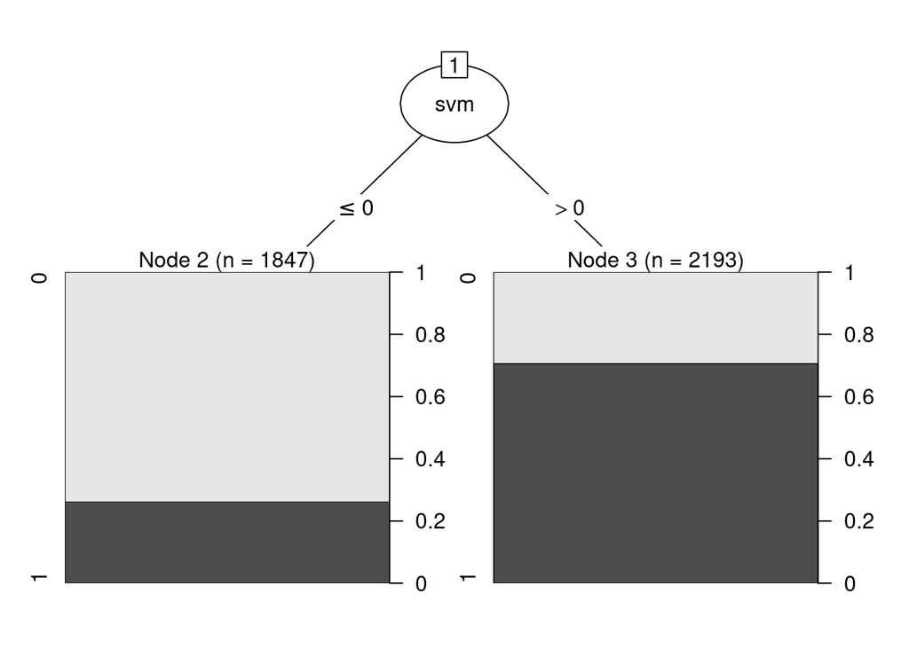

```r
predict_second_level <- predict(second_level_tree, val_data)

plot(second_level_tree)
```

```r
library(caret)
confusionMatrix(predict_second_level, as.factor(val_data$GFI_labels))
```

```
## Confusion Matrix and Statistics
##
##           Reference
## Prediction   0   1
##          0 614 205
##          1 278 635
##
##                Accuracy : 0.7211
##                  95% CI : (0.6994, 0.7422)
##     No Information Rate : 0.515
##     P-Value [Acc > NIR] : < 2.2e-16
##
##                   Kappa : 0.4432
##
##  Mcnemar's Test P-Value : 0.001052
##
##             Sensitivity : 0.6883
##             Specificity : 0.7560
##          Pos Pred Value : 0.7497
##          Neg Pred Value : 0.6955
##              Prevalence : 0.5150
##          Detection Rate : 0.3545
##    Detection Prevalence : 0.4729
##       Balanced Accuracy : 0.7221
##
##        'Positive' Class : 0
##
```

# 3 Decision Predictions

(Jim Harbaugh please read this part)

We will now create a function that uses the trained model to determine if a team should “Go For It” on 4th Down.

## 3.1 Stacked Logistic Model

### 3.1.1 Training

```r
stacked_glm <- glm(GFI_labels ~ . - knn, data = train_data)
stacked_glm <- step(stacked_glm, direction = "backward")
```

```
## Start:  AIC=4932.9
## GFI_labels ~ (glm + knn + ann + svm + tree) - knn
##
##        Df Deviance    AIC
## - ann   1   799.86 4932.0
## <none>      799.65 4932.9
## - tree  1   803.28 4949.2
## - glm   1   803.84 4952.0
## - svm   1   843.49 5146.6
##
## Step:  AIC=4932.01
## GFI_labels ~ glm + svm + tree
##
##        Df Deviance    AIC
## <none>      799.86 4932.0
## - tree  1   803.59 4948.8
## - glm   1   804.39 4952.8
## - svm   1   845.46 5154.0
```

```r
summary(stacked_glm)
```

```
##
## Call:
## glm(formula = GFI_labels ~ glm + svm + tree, data = train_data)
##
## Deviance Residuals:
##     Min       1Q   Median       3Q      Max
## -0.8088  -0.2767   0.2007   0.2955   0.8347
##
## Coefficients:
##             Estimate Std. Error t value Pr(>|t|)
## (Intercept)  0.15054    0.02195   6.859 8.01e-12 ***
## glm          0.26553    0.05556   4.779 1.82e-06 ***
## svm          0.31866    0.02101  15.168  < 2e-16 ***
## tree1        0.08835    0.02037   4.338 1.47e-05 ***
## ---
## Signif. codes:  0 '***' 0.001 '**' 0.01 '*' 0.05 '.' 0.1 ' ' 1
##
## (Dispersion parameter for gaussian family taken to be 0.1981822)
##
##     Null deviance: 1009.94  on 4039  degrees of freedom
## Residual deviance:  799.86  on 4036  degrees of freedom
## AIC: 4932
##
## Number of Fisher Scoring iterations: 2
```

As it turns out, the ann is also not that useful per the stacked glm, so it can be omitted from the function we create too.

## 3.2 Decision Function

Now we will define the actual decision function. The function requires as input a data frame with the following fields:

yardline_100, half_seconds_remaining, game_half, goal_to_go, ydstogo, play_type, shotgun, timeout, posteam_score, defteam_score, away_score, home_score, season, home_team, posteam, roof, down, posteam_timeouts_remaining, defteam_timeouts_remaining

It requires the following models:

```r
gfi <- function(df, stacked_glm, svm_model, tree, glm_model, oppteam) {
  df$game_half <- factor(df$game_half, levels(GFI_small$game_half))
  df$play_type <- factor(df$play_type, levels(GFI_small$play_type))

  model_outs <- data.frame(
    "glm" = predict(glm_model, newdata = df),
    "svm" = predict(svm_model, df),
    "tree" = predict(tree, df)
  )

  prob_success <- predict(stacked_glm, model_outs)

  pos_df <- df
  pos_df$down <- 1
  pos_df$ydstogo <- 10
  pos_df$yardline_100 <- pos_df$yardline_100 - pos_df$ydstogo

  success <- nflfastR::calculate_expected_points(pos_df) %>%
    dplyr::select(ep)

  opp_df <- df
  opp_df$posteam <- oppteam
  opp_df$down <- 1
  opp_df$ydstogo <- 10
  opp_df$yardline_100 <- 100 - pos_df$yardline_100

  failure <- nflfastR::calculate_expected_points(opp_df) %>%
    dplyr::select(ep)

  return(ifelse((prob_success * success$ep + (1 - prob_success) * failure$ep * -1) > 0, "Go For It", "Don't Go For It"))
}
```

Now that the function has been defined we need a scenario:

```r
input_1 <- data.frame(
  "yardline_100" = 10,
  "half_seconds_remaining" = 120,
  "game_half" = "Half1",
  "goal_to_go" = 0,
  "ydstogo" = 5,
  "play_type" = "run",
  "shotgun" = 0,
  "timeout" = 0,
  "posteam_score" = 21,
  "defteam_score" = 3,
  "away_score" = 3,
  "home_score" = 21,
  "season" = 2018,
  "home_team" = "DET",
  "posteam" = "DET",
  "roof" = "dome",
  "down" = 3,
  "posteam_timeouts_remaining" = 2,
  "defteam_timeouts_remaining" = 2
)
```

Run the function on the sample input

```r
gfi(input_1, stacked_glm, model_svm, model_tree, model_glm, "CHI")
```

```
##                 1
## "Don't Go For It"
```